# Cuestionario 2 · Estimación e Inferencia

Bioestadística y Diseño Experimental · Semana 1 · 2026-II

Autor/a

Maestría en Ecología y Biodiversidad · Universidad del Magdalena

Fecha de publicación

4 de octubre de 2026

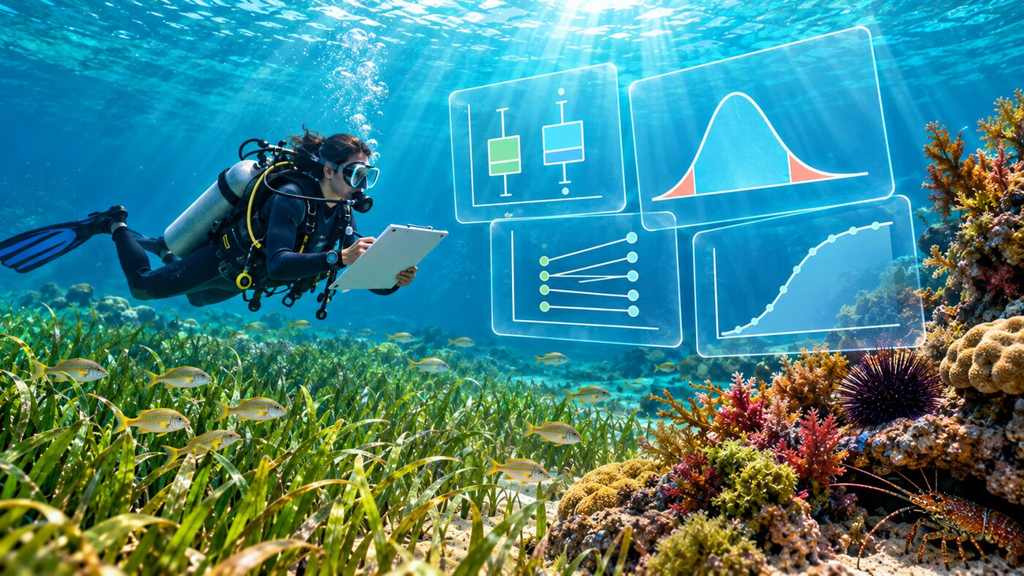

## Cómo usar este cuestionario

Este cuestionario complementa el Taller 2 y su práctica de opción múltiple (Cuestionario 1). Aquí el objetivo consiste en elegir e implementar correctamente la prueba de inferencia, y reconocer los errores de interpretación que con más frecuencia dañan un análisis de inferencia estadística.

- **Parte A — Elección e implementación:** se muestran cuatro escenarios posibles de inferencia; de entrada no se indica si hace falta un t-test, un ANOVA, una prueba no paramétrica o un cálculo de potencia.
- **Parte B — Identificación del error:** se muestran cuatro análisis ya “realizados”, cada uno con un error de inferencia — no de diseño (eso se trabajó en el Taller 1), sino de cómo se interpretó o ejecutó el análisis.
- **Parte C — Proyecto propio:** 2 preguntas que llevan el cierre del Taller 2 («Una base para el futuro proyecto de grado») a la idea de investigación propia.

**ImportanteRuta mínima calificable (45 pts · rúbrica R1)**

| Parte | Qué se entrega | Criterio de R1 |
| --- | --- | --- |
| **A — Elección e implementación** | **2 de los 4 escenarios** (A1 a A4), a elección | 1. Razonamiento y elección (20) · 2. Ejecución e interpretación (15) |
| **B — Identificación del error** | **2 de los 4 casos** (B1 a B4), a elección | 1. Razonamiento y elección · 2. Ejecución e interpretación |
| **C — Proyecto propio** | **C1 y C2** (obligatorias) | 3. Proyecto propio (10) |

- Al inicio de la entrega se indica qué escenarios y qué casos se eligieron. Si no se indica, se califican los dos primeros que aparezcan resueltos en cada parte.
- Los ejercicios que no forman parte de la ruta elegida quedan como práctica: no suman ni restan.
- Se entrega en Moodle el `.qmd` con la ruta mínima resuelta y su render (HTML o PDF). Cierra el **jueves 15 de octubre, 23:59**. La tarea se habilita al completar la práctica de opción múltiple (Cuestionario 1).

Las respuestas no se incluyen en esta versión: se discuten en clase después del cierre de la entrega. Conviene ejecutar el código de cada escenario y decidir la prueba antes de escribir la respuesta.

**Código**

```r
# library(tidyverse)  # descomentar si se tiene instalado
```

# Parte A — Elección e implementación de la prueba correcta

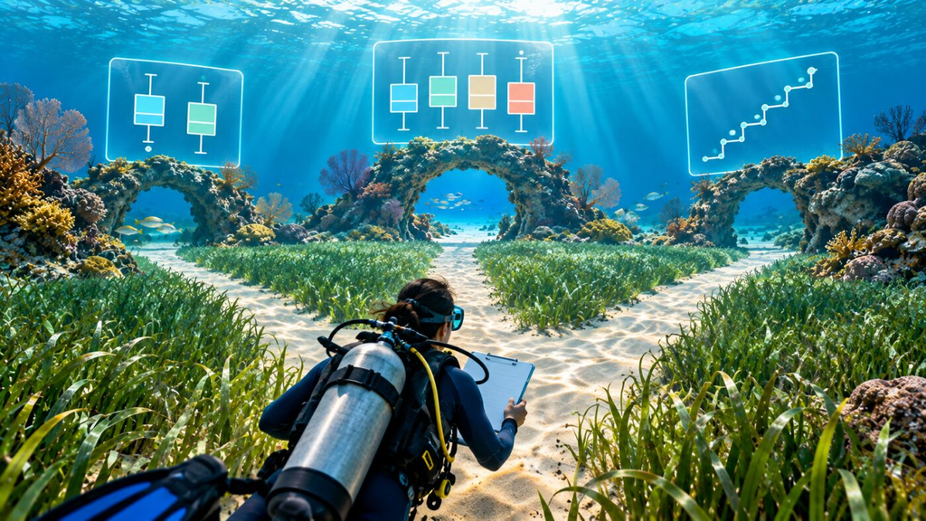

**Tip**

**Ruta mínima:** resolver **2 de los 4 escenarios** (A1 a A4), a elección. Los demás quedan como práctica.

## A1 — Talla de pargo y conectividad del manglar

**NotaEl contexto**

Un equipo quiere saber si la talla de juveniles de pargo (*Lutjanus* spp.) difiere entre manglares con **alta** y **baja** conectividad a praderas de pastos marinos cercanas. Se midieron 15 juveniles en cada tipo de manglar.

1. ¿Cuántos grupos hay, y qué tipo de prueba de la tabla de síntesis del taller se considera de entrada?
2. ¿Qué se necesita revisar antes de confiar en el resultado?

**Código**

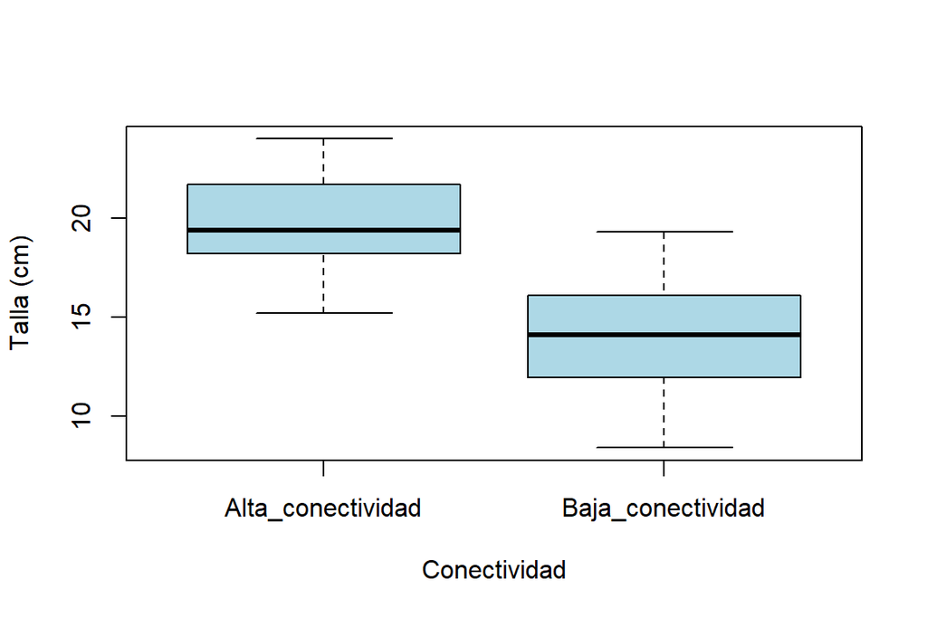

```r
set.seed(42)  # Fijar semilla

# Crear grupos
manglar <- gl(2, 15,
              labels = c("Alta_conectividad",
                         "Baja_conectividad"))

# Simular tallas
talla_pargo <- round(rnorm(30,
                           mean = c(18.5, 14.8)[as.integer(manglar)],
                           sd = 2.4), 1)

pargo_talla <- data.frame(manglar, talla_pargo)  # Crear base de datos

# Comparar gráficamente los grupos
boxplot(talla_pargo ~ manglar,
        data = pargo_talla,
        col = "lightblue",
        xlab = "Conectividad",
        ylab = "Talla (cm)")
```

## A2 — Densidad de erizos antes y después de una mortalidad masiva

**NotaEl contexto**

Tras un evento de mortalidad masiva (die-off) por una posible enfermedad, un equipo regresó a **los mismos 10 sitios** donde ya tenía datos de densidad de erizos (*Diadema antillarum*) previos al evento, y volvió a censar.

1. ¿Las dos mediciones son de sitios independientes, o del mismo sitio dos veces?
2. ¿Qué prueba corresponde?

**Código**

```r
set.seed(2026)  # Fijar semilla

n_sitios2 <- 10  # Definir número de sitios

# Simular densidad inicial
densidad_antes <- round(rnorm(n_sitios2,
                              mean = 12,
                              sd = 3), 1)

# Simular mortalidad
mortalidad <- round(rnorm(n_sitios2,
                          mean = 7,
                          sd = 2), 1)

# Calcular densidad posterior
densidad_despues <- round(pmax(0, densidad_antes - mortalidad), 1)

# Crear base de datos
erizos_dieoff <- data.frame(sitio = paste0("S", 1:n_sitios2),
                            densidad_antes,
                            densidad_despues)

erizos_dieoff  # Visualizar los datos
```

```
   sitio densidad_antes densidad_despues
1     S1           13.6              7.4
2     S2            8.8              3.3
3     S3           12.4              5.8
4     S4           11.7              5.2
5     S5           10.0              8.1
6     S6            4.5              0.0
7     S7            9.8              1.6
8     S8            8.9              1.5
9     S9           12.3              6.9
10   S10           10.6              2.2
```

## A3 — Clorofila-a en cuatro estaciones de una bahía

**NotaEl contexto**

Un equipo de monitoreo mide la concentración de clorofila-a (indicador de eutrofización) en **4 estaciones** de una bahía, con distinta influencia de escorrentía continental. Este tipo de variable ambiental suele tener una distribución muy asimétrica (muchos valores bajos, unos pocos muy altos).

1. ¿Cuántos grupos hay, y qué prueba se consideraría de entrada?
2. Antes de confiar en esa prueba, ¿qué se tiene que revisar — y qué se haría si falla?

**Código**

[figure not shown]

```r
set.seed(2026)  # Fijar semilla

# Crear grupos
estacion <- gl(4, 9,
               labels = c("E1_baja_escorrentia", "E2",
                          "E3", "E4_alta_escorrentia"))

# Asignar medias esperadas
lambda_chl <- c(3, 6, 10, 18)[as.integer(estacion)]

# Simular concentraciones
clorofila <- round(rgamma(36,
                          shape = 0.8,
                          rate = 0.8/lambda_chl), 2)

# Crear base de datos
bahia_chl <- data.frame(estacion, clorofila)

# Comparar gráficamente los grupos
boxplot(clorofila ~ estacion,
        data = bahia_chl,
        col = "lightblue",
        xlab = "Estación",
        ylab = "Clorofila-a (µg/L)")
```

## A4 — Planeando un estudio: dragado y cobertura de pastos marinos

**NotaEl contexto**

Antes de salir a campo, un equipo quiere saber cuántas parcelas necesita por grupo para detectar una diferencia de **8 puntos porcentuales** de cobertura de pastos marinos entre zonas con y sin actividad de dragado reciente, con una potencia del 80%. Un estudio piloto previo, en un sistema similar, reportó una desviación estándar de 11 puntos porcentuales.

1. ¿Qué función de R (de las usadas en la Parte 7 del taller) responde esta pregunta?
2. ¿Qué le pasaría al `n` necesario si la variabilidad del sistema fuera mayor (sd = 15 en vez de 11)?

# Parte B — Identificación del error: diagnóstico de errores de inferencia

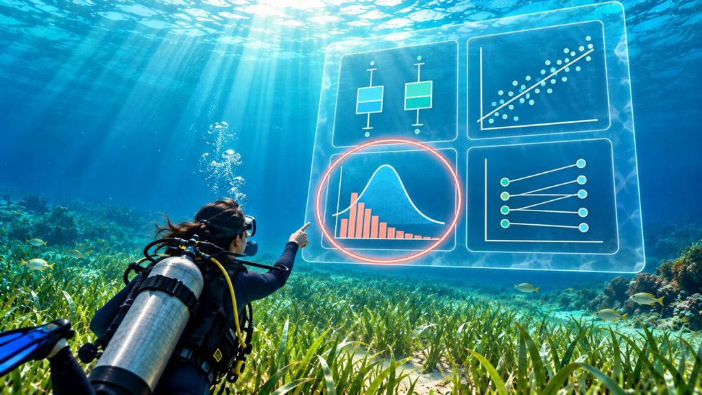

**Tip**

**Ruta mínima:** resolver **2 de los 4 casos** (B1 a B4), a elección. Los demás quedan como práctica.

Cada viñeta muestra un análisis ya “corrido”. Conviene identificar qué está mal antes de ver la respuesta.

## B1 — Tiempo de manipulación en tres zonas de pesca

**NotaContexto**

Un investigador compara el tiempo de manipulación de la captura entre pesca artesanal, semi-industrial e industrial (3 zonas). Sin revisar ningún supuesto, corrió directamente un ANOVA de una vía, obtuvo p = 0.0585, y concluyó que **no hay diferencias** entre tipos de pesca.

**Código**

```r
set.seed(1)  # Fijar semilla

# Crear grupos
zona_pesca <- gl(3, 12,
                 labels = c("Artesanal",
                            "Semi_industrial",
                            "Industrial"))

# Asignar medias esperadas
lambda_b1 <- c(4, 9, 7)[as.integer(zona_pesca)]

# Simular tiempos de manipulado
tiempo_manipulado <- round(rexp(36, rate = 1/lambda_b1), 1)

# Crear base de datos
manipulado <- data.frame(zona_pesca, tiempo_manipulado)
```

1. ¿Qué le faltó revisar antes de confiar en ese ANOVA?
2. ¿Cambia la conclusión si se revisa?

## B2 — “No significativo” interpretado como “no hay efecto”

**NotaContexto**

Un equipo comparó un sitio control contra un sitio con impacto antrópico reciente, con solo **6 réplicas por grupo** (limitación de tiempo de campo). El t-test dio p = 0.25, y el equipo concluyó en su informe: *“no hay evidencia de que el impacto antrópico afecte la variable medida”*.

**Código**

```r
set.seed(2026)  # Fijar semilla

n_chico <- 6  # Definir número de sitios

# Simular datos del sitio control
sitio_control <- round(rnorm(n_chico, mean = 40, sd = 9), 1)

# Simular datos del sitio impacto
sitio_impacto <- round(rnorm(n_chico, mean = 34, sd = 9), 1)
```

1. Con solo 6 réplicas por grupo, ¿qué tan probable es que el estudio detecte un efecto moderado aunque exista de verdad?
2. ¿Es correcto decir que “no hay efecto”, o sería más preciso decir otra cosa?

## B3 — Ignorar el pareo

**NotaContexto**

Retomando el diseño de A2 (mismos sitios, antes/después de la mortalidad masiva de erizos), un asistente de investigación analizó los datos con un t-test de dos muestras **independientes**, en vez de pareado, “porque son solo dos columnas de números”.

**Código**

```r
set.seed(2026)  # Fijar semilla

n_par <- 10  # Definir número de pares

# Simular mediciones antes
antes_b3 <- round(rnorm(n_par, mean = 25, sd = 6), 1)

# Simular cambio entre mediciones
cambio_b3 <- round(rnorm(n_par, mean = 5, sd = 1.5), 1)

# Calcular mediciones después
despues_b3 <- round(antes_b3 - cambio_b3, 1)
```

1. ¿Qué información usa el t-test pareado que el independiente ignora por completo?
2. ¿Qué se espera que le pase a la conclusión si se tratan datos pareados como independientes?

## B4 — Comparaciones múltiples sin corrección

**NotaContexto**

Un estudiante compara una variable entre 4 grupos experimentales. En vez de correr un solo ANOVA, decidió correr un **t-test independiente para cada par posible de grupos** (6 comparaciones en total), y reportó como “hallazgo” la única comparación que dio p < 0.05.

**Código**

```r
set.seed(2026)  # Fijar semilla

# Crear grupos
grupo_b4 <- gl(4, 10,
               labels = c("G1", "G2", "G3", "G4"))

# Simular valores
valor_b4 <- round(rnorm(40, mean = 20, sd = 5), 1)

# Crear base de datos
datos_b4 <- data.frame(grupo_b4, valor_b4)
```

1. Si se repite una prueba con α = 0.05 muchas veces, aunque no exista ningún efecto real, ¿qué probabilidad hay de que **al menos una** salga “significativa” solo por azar?
2. ¿Qué debió haberse corrido en su lugar?

# Parte C — Proyecto propio

**Tip**

**Ruta mínima:** **C1 y C2 son obligatorias**. Se califican con el criterio 3 de la rúbrica R1 (10 pts).

Esta parte retoma el cierre del Taller 2 («Una base para el futuro proyecto de grado»): la actividad en clase (C1) y la tarea corta (C2). Se trabaja sobre la misma idea tentativa del Cuestionario 2 del Taller 1, si ya se planteó. No hay una respuesta única: se valora que la aplicación sea coherente con el tema del taller y específica para el sistema de estudio, no una copia de los ejemplos del taller.

## C1 — De la idea tentativa a la prueba

**NotaLa consigna**

Escribir en una frase la idea tentativa de investigación. A partir de ella:

1. ¿Cuál sería la variable respuesta y de qué tipo es (continua, conteo, proporción)? ¿Cuántos grupos o niveles se compararían, y las mediciones serían independientes o pareadas (el mismo sitio o individuo medido dos veces)?
2. Según la tabla de síntesis de las diapositivas, ¿qué prueba se usaría de entrada, qué supuestos habría que revisar y cuál sería la alternativa si alguno falla?

## C2 — Ensayar el análisis con datos simulados

**NotaLa consigna**

1. Copiar la sección del Taller 2 que más se parezca al análisis propuesto en C1 (Parte 2: t-test o t-test pareado; Parte 3: ANOVA de una vía) y cambiar los nombres de las variables y las medias simuladas por valores plausibles para el sistema de estudio propio. Indicar de dónde salen esos valores (literatura, estudio piloto o criterio propio).
2. Ejecutar `shapiro.test()`, `bartlett.test()` (si hay grupos) y la prueba correspondiente. ¿La salida de R tiene sentido con lo planteado? Interpretar el resultado en términos ecológicos: sentido y magnitud de la diferencia, no solo el valor p.

**Código**

```r
# Reemplazar este bloque por la simulación propia y cambiar
# "eval: false" por "eval: true" antes de renderizar.
set.seed(2026)                                        # Fija semilla

# grupo <- gl(...)                                    # Crea grupos
# respuesta <- rnorm(...)                             # Genera respuesta
# datos_propios <- data.frame(grupo, respuesta)       # Crea tabla
# mod_propio <- aov(respuesta ~ grupo, data = datos_propios)  # Ajusta modelo
# shapiro.test(residuals(mod_propio))                 # Revisa normalidad
# bartlett.test(respuesta ~ grupo, data = datos_propios)      # Revisa varianzas
```

# Cierre

Los 8 ejercicios de las Partes A y B apuntan a la misma habilidad desde ángulos distintos: elegir la herramienta de inferencia correcta para cada pregunta, y reconocer cuándo un análisis —propio o de otra persona— tiene un problema que ningún valor-p realizado puede ocultar. Es exactamente el tipo de revisión que un jurado de tesis, o un revisor de artículo, le hará al propio trabajo — mejor practicarlo ahora, con datos simulados, que descubrirlo tarde con los datos propios.

## Referencias

Los escenarios de esta guía son de elaboración propia para este curso; no reproducen ejercicios ni datos de las fuentes citadas en el Taller 2.